# Bolas_Lab10 Interpolation

### Show where the difference between IDW and OK is within the 95% confidence limit of the OK prediction.(Show where the IDW interpolation is within the 95% confidence limit of the OK prediction)

Think of variance map as the mathmatical term “variance.” In other words, standard deviation is the square root of variance. The 95% confidence interval is 1.96 standard deviations. Just like before, can do math on this raster. But, don’t find the the difference, do the opposite of the difference.

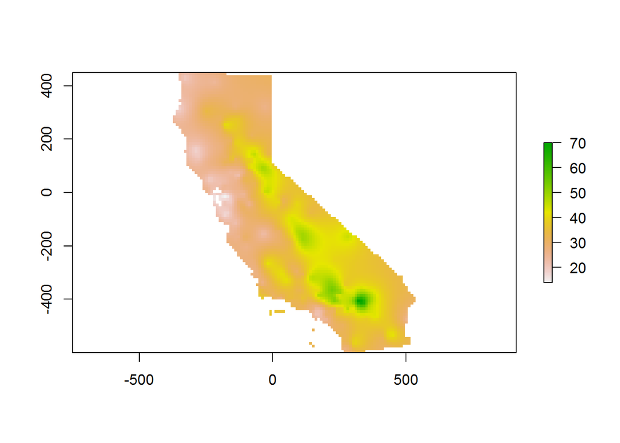

```r
#get 95% ci map
#ok1ci<-1.96*(sqrt(ok1[[2]]))
#this doesn't work because when pulling from a sample data set, you need to include the size of the sample. x has 452 features

ok1ci1 <- 1.96 * (sqrt((ok1[[2]])/452))

#two maps, one with the upper confidence interval added to the prediction, one with the lower confidence interval
upperci <- ok1[[1]] +ok1ci1
lowerci <- ok1[[1]] -ok1ci1
plot(upperci)
```

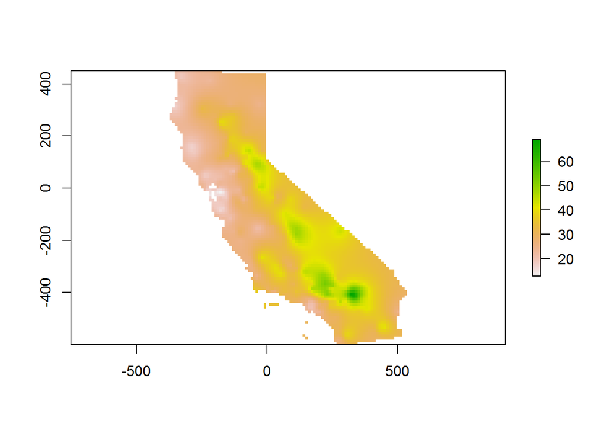

```r
plot(lowerci)
```

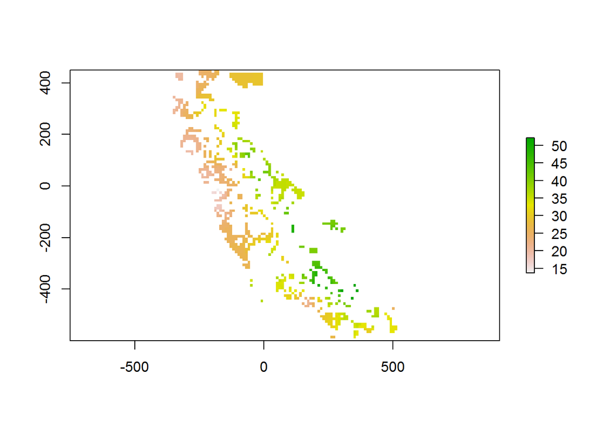

```r
#need to only keep the parts of upper and lower that overlap with IDW
#idwoz2 <- idwoz1[idwoz1 >= lowerci & idwoz1 <= upperci]
#plot(idwoz2)
#this doesn't work! try something different

#lets try making a new object, then changing things in the oject

idwoz3 <- idwoz1
idwoz3[idwoz3 <= lowerci | idwoz3 >= upperci] <- NA
plot(idwoz3)
```

### Question 9: Can you describe the pattern we are seeing, and speculate about what is causing it?

This map shows the overlap between the IDW map and the points for the kirging method that were within the 95% confidence interval. Maybe another way to think about it is, these are the points where the kriging method was relatively certain the interpolation was correct and the IDW aggrees.

### Question 10: Bonus question. Can you use the optim function to find the intercept and slope that is returned by lm (see below)

```r
set.seed(0) #the random deviates that y will use, sets this so its the same each time
x <- 1:10 #x is numbers 1-10
y <- runif(10) + 1:10/4

lm(y~x)
```

```
##
## Call:
## lm(formula = y ~ x)
##
## Coefficients:
## (Intercept)            x
##      0.5186       0.2712
```

```r
##
## Call:
## lm(formula = y ~ x)
##
## Coefficients:
## (Intercept)            x
##      0.5186       0.2712

y #is 10 observations that are random deviates from the uniform distribution. for each observation, add 1/4, 2/4, etc
```

```
##  [1] 1.1466972 0.7655087 1.1221239 1.5728534 2.1582078 1.7016819 2.6483897
##  [8] 2.9446753 2.9107978 3.1291140
```

```r
#Optim finds best parameters. You provide initial values and optim finds the best ones.
#for optim, 1st arg, par= parameter values; 2nd arg, fn= function

#write a function for linear regression?

#best <- optim(par= c(x,y), fn=lm) this doesn't work
```

# Bonus: Comparing Ozone (O3) + Nitrogen Dioxide (NO2)

### 1. Interpolate NO2

```r
x2 <- read.csv(file.path(datapath, "airqual.csv"))

#there are na's in the df
x2 <- x2[!is.na(x2$NO2DLYAV),] # we need the comma here

#get NO2 data in better units
x2$NO2DLYAV <- x2$NO2DLYAV * 1000

#add coordinate and transform
coordinates(x2) <- ~LONGITUDE + LATITUDE
proj4string(x2) <- CRS('+proj=longlat +datum=NAD83')
TA <- CRS("+proj=aea +lat_1=34 +lat_2=40.5 +lat_0=0 +lon_0=-120 +x_0=0 +y_0=-4000000 +datum=NAD83 +units=km +ellps=GRS80")

aq2 <- spTransform(x2, TA) #air quality data in the TA CRS
class(aq2)
```

```
## [1] "SpatialPointsDataFrame"
## attr(,"package")
## [1] "sp"
```

```r
#head(aq2)

#g #CA counties as a spatial grid with the TA projection

#make a variogram
gsNO2 <- gstat(formula=NO2DLYAV~1, locations=aq2)
vNO2 <- variogram(gsNO2, width=20)

#fit the variogram
fveNO2 <- fit.variogram(vNO2, vgm(85, "Exp", 75, 20))
fveNO2
```

```
##   model     psill    range
## 1   Nug  37.78955  0.00000
## 2   Exp 104.64114 76.64037
```

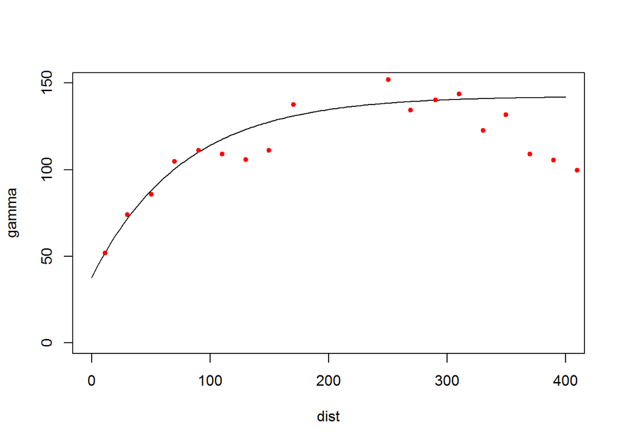

```r
plot(variogramLine(fveNO2, 400), type='l', ylim=c(0,150))
points(vNO2[,2:3], pch=20, col='red')
```

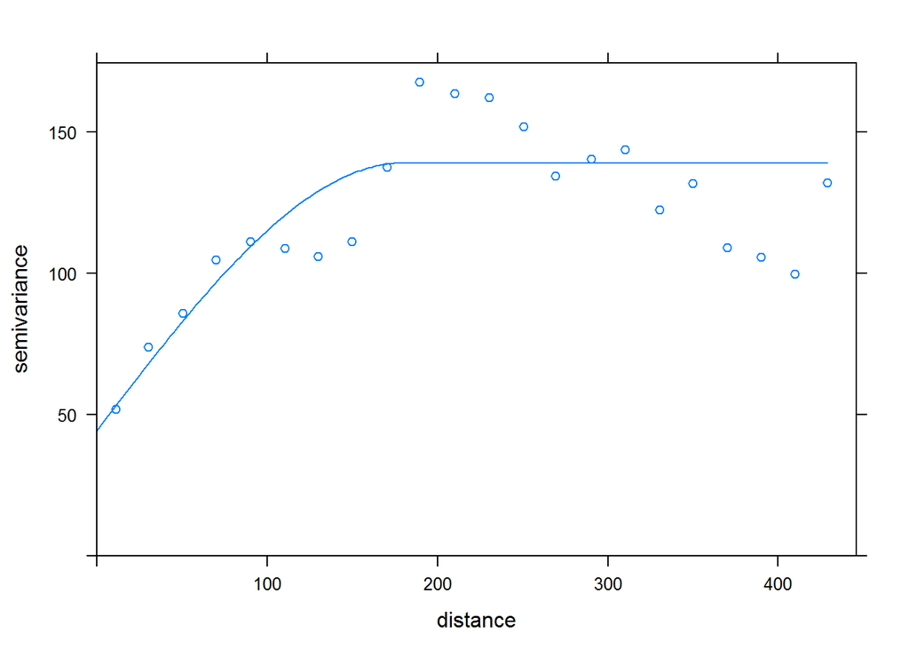

```r
fvsNO2 <- fit.variogram(vNO2, vgm(85, "Sph", 75, 20))
plot(vNO2, fvsNO2)
```

```r
#Not sure it matters which model to use, but I'll stick with exponential since that's what I used before

#Krig!!!!
kNO2 <- gstat(formula=NO2DLYAV~1, locations=aq2, model=fveNO2)

kNO2p <- predict(kNO2, g)
```

```
## [using ordinary kriging]
```

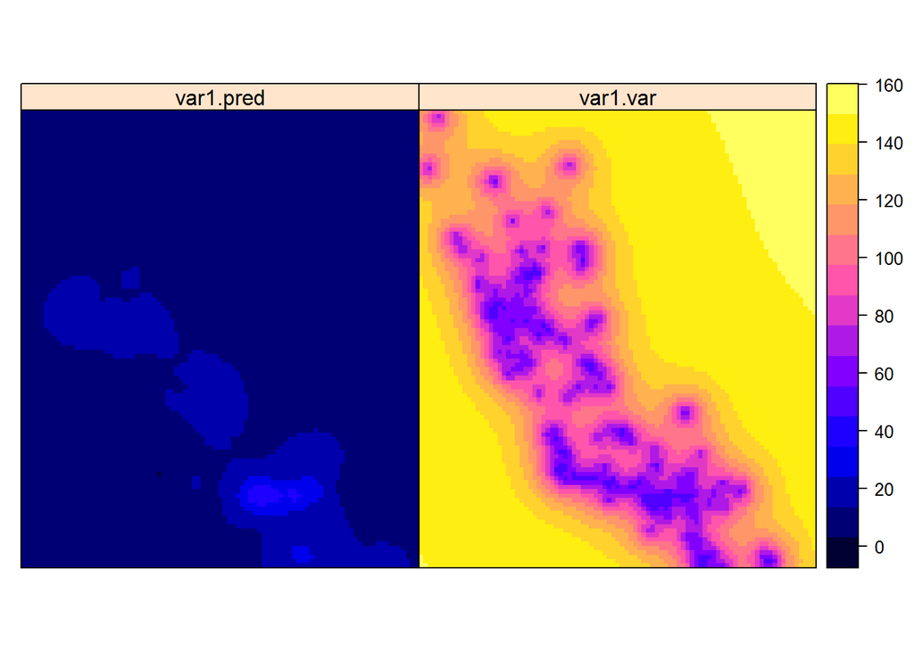

```r
## [using ordinary kriging]
spplot(kNO2p)
```

```r
class(kNO2p)
```

```
## [1] "SpatialGridDataFrame"
## attr(,"package")
## [1] "sp"
```

```r
#make it look good

NO2k <- brick(kNO2p) #raster brick
NO2k
```

```
## class       : RasterBrick
## dimensions  : 105, 91, 9555, 2  (nrow, ncol, ncell, nlayers)
## resolution  : 10, 10  (x, y)
## extent      : -373.9761, 536.0239, -599.9775, 450.0225  (xmin, xmax, ymin, ymax)
## coord. ref. : +proj=aea +lat_1=34 +lat_2=40.5 +lat_0=0 +lon_0=-120 +x_0=0 +y_0=-4000000 +datum=NAD83 +units=km +ellps=GRS80 +towgs84=0,0,0
## data source : in memory
## names       : var1.pred,  var1.var
## min values  :  2.741371, 46.427247
## max values  :  40.58377, 149.81147
```

```r
class(NO2k)
```

```
## [1] "RasterBrick"
## attr(,"package")
## [1] "raster"
```

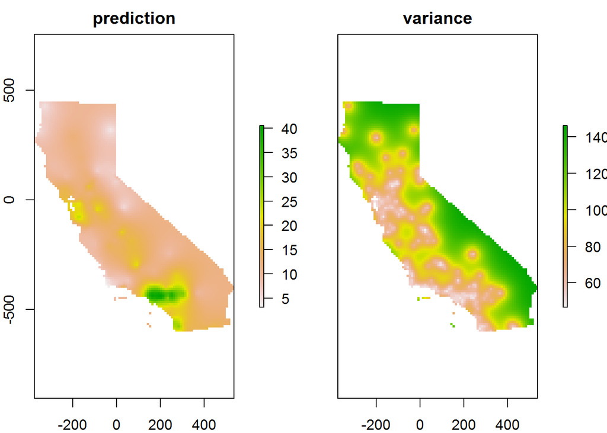

```r
NO2k2 <- mask(NO2k, catrans) #use catrans bc its the raster layer of counties
names(NO2k2) <- c('prediction', 'variance')
plot(NO2k2)
```

```r
class(NO2k2)
```

```
## [1] "RasterBrick"
## attr(,"package")
## [1] "raster"
```

### 2. Once you have an interpolation ﬁeld for both O3 and NO2, compare the results by calculating the 5 number summary for both variables (min, 1st quartile, median, 3rd quartile, max) [hint summary ()]

```r
summary(NO2k2)
```

```
##           var1.pred   var1.var
## Min.       3.120751   46.42725
## 1st Qu.    9.716651   81.00752
## Median    11.503114  100.03123
## 3rd Qu.   14.068330  122.26790
## Max.      40.583769  146.31379
## NA's    5468.000000 5468.00000
```

```r
#         var1.pred   var1.var
#Min.       3.120751   46.42725
#1st Qu.    9.716651   81.00752
#Median    11.503114  100.03123
#3rd Qu.   14.068330  122.26790
#Max.      40.583769  146.31379
#NA's    5468.000000 5468.00000

summary(ok1)
```

```
##          var1.pred   var1.var
## Min.      13.25344   27.77732
## 1st Qu.   27.49733   46.92070
## Median    33.13652   58.08494
## 3rd Qu.   37.91154   75.83650
## Max.      69.46779  107.40890
## NA's    5468.00000 5468.00000
```

```r
#        var1.pred   var1.var
#Min.      13.25344   27.77732
#1st Qu.   27.49733   46.92070
#Median    33.13652   58.08494
#3rd Qu.   37.91154   75.83650
#Max.      69.46779  107.40890
#NA's    5468.00000 5468.00000
```

### 3. Using the spatial autocorrelation functions in the raster package calculate the Moran’s I, and Gi for both pollutants. And plot the results for Gi.

Moran’s and Geary for ozone

```r
##OZ
#if using Moran(), it takes a raster layer and a spatial weights matrix, same for LocalGeary

#using inverse distance weights since that's what is used in other Moran's I calculations. Doesn't make sense to do with kriging  since that comes with it's own error estimate

#Moran's I for oz
class(idwoz1) #is a rasterlayer
```

```
## [1] "RasterLayer"
## attr(,"package")
## [1] "raster"
```

```r
Moran(idwoz1)
```

```
## [1] 0.9424728
```

```r
#1] 0.9424728 Mi = 0 means random, data is positively autocorrelated


#Gi for oz. GearyLocal only returns a raster layer, not a number, so I'm doing Geary for the number, and GearyLocal to plot
Gcoz <- Geary(idwoz1)
Gcoz #[1] 0.01969853 means positive autocorrelation, far from 1 means more positive (over 1 means negative, 1 means random)
```

```
## [1] 0.01969853
```

```r
Gioz<-GearyLocal(idwoz1)
Gioz
```

```
## class       : RasterLayer
## dimensions  : 105, 91, 9555  (nrow, ncol, ncell)
## resolution  : 10, 10  (x, y)
## extent      : -373.9761, 536.0239, -599.9775, 450.0225  (xmin, xmax, ymin, ymax)
## coord. ref. : +proj=aea +lat_1=34 +lat_2=40.5 +lat_0=0 +lon_0=-120 +x_0=0 +y_0=-4000000 +datum=NAD83 +units=km +ellps=GRS80 +towgs84=0,0,0
## data source : in memory
## names       : layer
## values      : 0, 6.210822  (min, max)
```

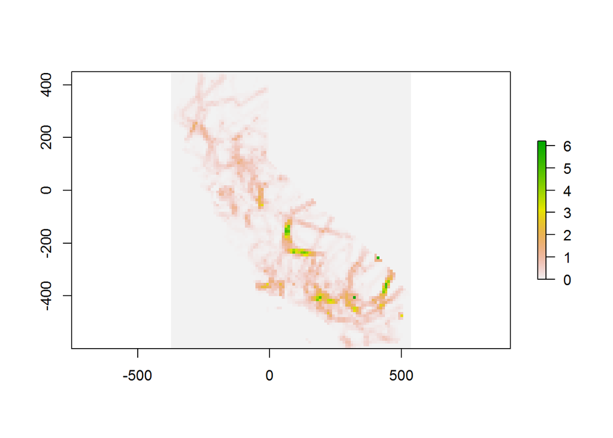

```r
plot(Gioz)
```

```r
##NO2
#need inverse distance weights for NO2

idmNO2 <- gstat(formula=NO2DLYAV~1, locations=aq2)
idpNO2 <- interpolate(rca, idmNO2) #rca us raster of counties, related to g
```

```
## [inverse distance weighted interpolation]
```

```r
## [inverse distance weighted interpolation]
idpNO2 <- mask(idpNO2, catrans)
idpno <- idpNO2

#this is an idw prediction, but it isn't with the optimal parameters.

#optim function finds IDW parameters (distance decay and nearest neighbors). You provide initial values and optim finds the best ones.

RMSE <- function(observed, predicted) {
  sqrt(mean((predicted - observed)^2, na.rm=TRUE))
}


f2 <- function(x2, test, train) {
  nmx <- x2[1]
  idpno <- x2[2]
  if (nmx < 1) return(Inf)
  if (idpno < .001) return(Inf)
  m <- gstat(formula=NO2DLYAV~1, locations=train, nmax=nmx, set=list(idp=idpno))
  p2 <- predict(m, newdata=test, debug.level=0)$var1.pred
  RMSE(test$NO2DLYAV, p2)
}
set.seed(20150518)
i <- sample(nrow(aq2), 0.2 * nrow(aq2))
tst <- aq2[i,]
trn <- aq2[-i,]
opt2 <- optim(c(8, .5), f2, test=tst, train=trn)
opt2
```

```
## $par
## [1] 6.7888942 0.5592996
##
## $value
## [1] 7.852719
##
## $counts
## function gradient
##       55       NA
##
## $convergence
## [1] 0
##
## $message
## NULL
```

```r
#$par
#[1] 6.7888942 0.5592996

#$value
#[1] 7.852719

#$counts
#function gradient
#      55       NA

#$convergence
#[1] 0

#$message
#NULL

#optimal IDW
nox <- gstat(formula=NO2DLYAV~1, locations=aq2, nmax=opt$par[1], set=list(idp=opt$par[2]))

idwNO2 <- interpolate(rca, nox)
```

```
## [inverse distance weighted interpolation]
```

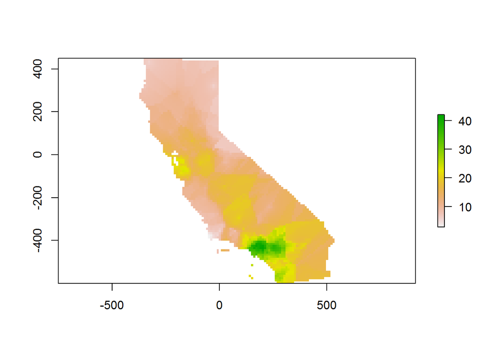

```r
## [inverse distance weighted interpolation]
idwNO22 <- mask(idwNO2, catrans)
plot(idwNO22)
```

```r
Moran(idwNO22)
```

```
## [1] 0.9355682
```

```r
#[1] 0.9355682

Geary(idwNO22)
```

```
## [1] 0.026598
```

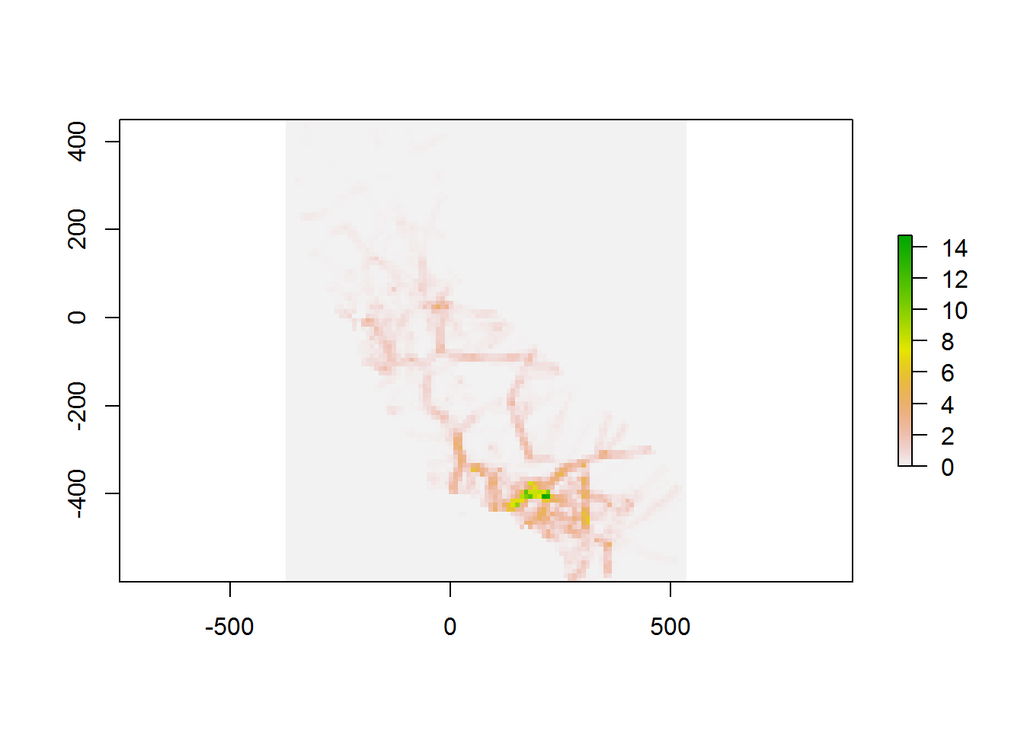

```r
#[1] 0.026598

GiNO2<-GearyLocal(idwNO22)

plot(GiNO2)
```

#### a) Do the results suggest spatial autocorrelation, if so which variable demonstrates greater correlation?

Both variables are spatially autocorrelated. The Moran’s I is almost identical between the two, with ozone having a slightly higher MI. With Geary’s smaller values occur when similar values are neighbors. Ozone has the smaller number, so again, it demonstrates higher autocorrelation.

#### b) How are neighbors deﬁned by these functions? [Hint check the help ﬁle]

Neighbors are 3x3 Queen’s case

#### c) Using this information can you calculate the Moran’s I with a different deﬁnition of neighborhood?

You can change how the weights matrix is created to change the neighbor definition. For example, by using the IDW as a matrix with Moran’s you get a different MI:

```r
idwoz1matrix<- as.matrix(idwoz1)
Moran(idwoz1, idwoz1matrix)
```

```
## [1] 0.05240405
```

```r
#[1] 0.05240405
```

#### d) Can you calculate the Gi*?

### 4. For 2 and 3 as there are only two raster layers so you might have just duplicate all lines of code for both variables, but if you were comparing a larger number of variables that would get cumbersome. Try calculating the summary and spatial autocorrelation values for both variables using the apply() family of functions?

```r
#1st arg, i want to do something to each column in df x2
names(x2) #tells me which columns are air pollution variables
```

```
##  [1] "LOCATION"   "SITE_NAME"  "SHORT_NAME" "CH4MAX1H"   "CH4DLYAV"
##  [6] "COMAX8N"    "COMXN8N"    "COMAX8O"    "COMAX1HR"   "CODLYAVG"
## [11] "H2SDLYAV"   "NMHCMX1H"   "NMHCDAVG"   "NO2MAX1H"   "NO2DLYAV"
## [16] "NOMAX1HR"   "NODLYAV"    "NOXMAX1H"   "NOXDLYAV"   "OZMAX1HR"
## [21] "OZHMX1HR"   "OZMAX8O"    "OZH1MX8O"   "OZDLYAV"    "OZMX8ST"
## [26] "OZHMX8ST"   "SO2MAX1H"   "SO2MX24N"   "SO2MX24O"   "SO2DLYAV"
## [31] "SULFURMX"   "THCMAX1H"   "THCDLYAV"   "TRSMAX1H"   "DAYOFWK"
```

```r
class(x2) #already spatialpoints df
```

```
## [1] "SpatialPointsDataFrame"
## attr(,"package")
## [1] "sp"
```

```r
#I'm trying to tell it to give me the summary of each column in x2, but it isn't recognizing summary as a function
#lapply(4:34(x2), FUN=summary)
```